# Option B — an estimate for a defined area

06 October 2026

**SYNTHETIC stratified survey — calculation demonstration**

> ⚠️ **Teaching example.** The reporting boundary in this report is **hypothetical** — drawn to show how the calculation works, not a mapped meadow. The area, the total and anything that depends on them describe no real place.

> ⚠️ **Synthetic data.** Every core in this report was generated by a computer to demonstrate the calculation. None of it is a field observation.

## 1. The question

How much sediment organic carbon is in this (synthetic) eelgrass area, and how precisely do the cores pin down the mean?

## 2. Area, habitat and sampling

| Area and habitat | SYNTHETIC eelgrass area: dense meadow, sparse meadow, and a channel edge that was not sampled |
| --- | --- |
| Reporting boundary | SYNTHETIC_boundary.csv — 6.2 ha (**hypothetical**) |
| Survey dates | SYNTHETIC — 15 July 2026 |
| Sampling design | Stratified random: plots placed at random within the dense and sparse strata (synthetic) |
| Sampling unit | one plot (100 m²); cores sharing a Plot ID are averaged first |
| Independent sampling units | 11 (from 12 complete cores) |
| Data source | Generated by data-raw/build_workbooks.py (seed 2026). Not field data. |

**Stratified random sampling** — random placement within each stratum; strata are weighted by their area.

## 3. The estimate — 0–30 cm, fully measured

**Sediment organic carbon** only. This is a stock — the carbon in the sediment now — not a rate of accumulation and not removal of carbon from the atmosphere. Every core reached 30 cm, so this figure is **measured**: nothing below the base of any core is in it.

**Mean 26.7 Mg C/ha over 5.6 ha: about 151 Mg C in the top 30 cm of sediment (hypothetical area). 90% interval: 21.5–31.9 Mg C/ha, or 121–180 Mg C in total (±19% of the mean; the planning target was ±20%, which was met).**

Sampling units, 0–30 cm (Mg C/ha)

| Unit | Stratum | Cores | Measured | Estimated | Total |
| --- | --- | --- | --- | --- | --- |
| SYN-D1 | dense | 1 | 19.8 | 0.0 | 19.8 |
| SYN-D2 | dense | 1 | 29.8 | 0.0 | 29.8 |
| SYN-D3 | dense | 2 | 35.9 | 0.0 | 35.9 |
| SYN-D4 | dense | 1 | 24.2 | 0.0 | 24.2 |
| SYN-D5 | dense | 1 | 33.0 | 0.0 | 33.0 |
| SYN-D6 | dense | 1 | 47.4 | 0.0 | 47.4 |
| SYN-S1 | sparse | 1 | 17.9 | 0.0 | 17.9 |
| SYN-S2 | sparse | 1 | 15.4 | 0.0 | 15.4 |
| SYN-S3 | sparse | 1 | 30.1 | 0.0 | 30.1 |
| SYN-S4 | sparse | 1 | 8.0 | 0.0 | 8.0 |
| SYN-S5 | sparse | 1 | 19.6 | 0.0 | 19.6 |

By stratum. The area mean weights each sampled stratum by its area.

| Stratum | Area (ha) | Sampling units | Mean (Mg C/ha) | SD among units |
| --- | --- | --- | --- | --- |
| dense | 3.6 | 6 | 31.7 | 9.7 |
| sparse | 2.1 | 5 | 18.2 | 8.0 |
| channel_edge | 0.6 | 0 | not sampled |  |

**What the interval includes.** It describes how much the mean could differ because a different set of sampling units might have been drawn. The area was treated as continuous (no finite-population correction). It does not include laboratory error, error in the LOI-to-carbon conversion, error in any estimated part below the cores, error in the boundary or stratum areas, or bias from cores that did not recover the full profile.

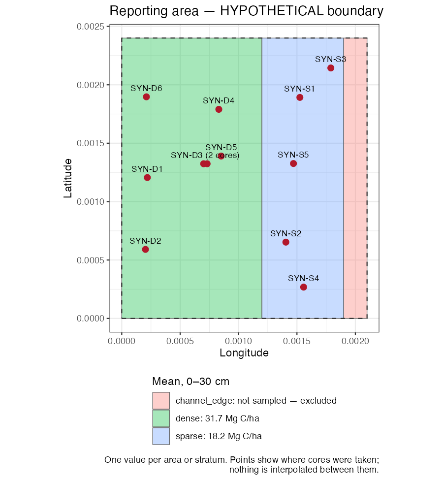

The map shows the reporting area, where the cores were taken and one value per area or stratum. Nothing is mapped between the points: the estimate is an area average, not a map of where the carbon is.

**Depths not reported.** Following Janousek et al. (2025), a stock is reported to 30 cm only for cores at least 20 cm long, to 50 cm for cores at least 35 cm and to 100 cm for cores at least 75 cm:

- 0–50 cm — needs every core to reach 35 cm; too short: SYN-S2.
- 0–100 cm — needs every core to reach 75 cm; too short: SYN-D1, SYN-D2, SYN-D3a, SYN-D3b, SYN-D4, SYN-D5, SYN-D6, SYN-S1, SYN-S2, SYN-S3, SYN-S4, SYN-S5.

## 5. How was depth estimated?

Nothing in the estimate above was extrapolated. This section shows how a deeper figure would be built, for reference.

| Core | Measured to (cm) | Estimated below the core with | Why not the core’s own curve | Why not the pooled curve | Curve floor (mg C/cm³) |
| --- | --- | --- | --- | --- | --- |
| SYN-D1 | 46.0 | this core’s decay curve |  |  | 4.6 |
| SYN-D2 | 35.0 | this core’s decay curve |  |  | 6.4 |
| SYN-D3a | 44.0 | this core’s decay curve |  |  | 6.8 |
| SYN-D3b | 46.0 | this core’s decay curve |  |  | 7.1 |
| SYN-D4 | 45.0 | this core’s decay curve |  |  | 4.1 |
| SYN-D5 | 45.0 | this core’s decay curve |  |  | 7.3 |
| SYN-D6 | 42.0 | this core’s decay curve |  |  | 10.5 |
| SYN-S1 | 36.0 | this core’s decay curve |  |  | 3.8 |
| SYN-S2 | 33.0 | this core’s decay curve |  |  | 3.7 |
| SYN-S3 | 46.0 | this core’s decay curve |  |  | 6.8 |
| SYN-S4 | 45.0 | this core’s decay curve |  |  | 2.2 |
| SYN-S5 | 46.0 | this core’s decay curve |  |  | 4.6 |

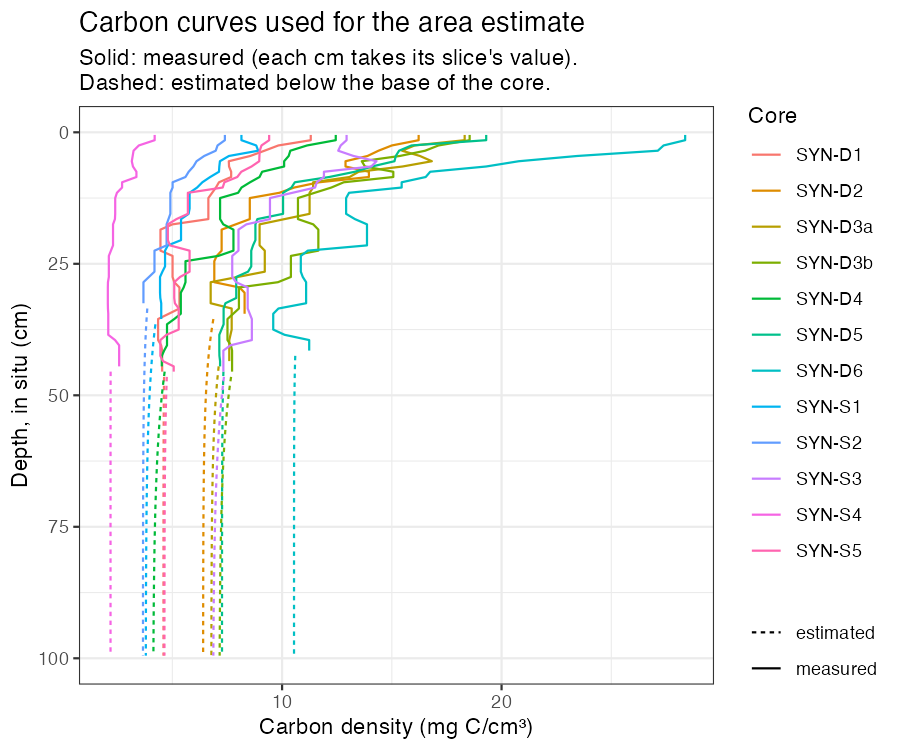

Every standard depth, and whether it could be reported.

| Depth | Status | Mean (Mg C/ha) | Total (Mg C) | Interval (Mg C/ha) | % estimated |
| --- | --- | --- | --- | --- | --- |
| 0–15 cm | measured | 16.1 | 91 | 12.9–19.3 | 0 |
| 0–30 cm | measured | 26.7 | 151 | 21.5–31.9 | 0 |
| 0–50 cm | not reported |  |  | — |  |
| 0–100 cm | not reported |  |  | — |  |

## 6. Notes from the calculation

- Unsampled strata excluded: channel_edge (0.59 ha). The estimate and total cover the sampled strata only.
- The interval describes sampling variation among sampling units only. It does not include laboratory error, uncertainty in the LOI-to-carbon conversion, uncertainty in the estimated (extrapolated) part of each core, error in the boundary or stratum areas, or bias from cores that did not recover the full profile.

## 7. Missing data, exclusions and limitations

- No cores were left out by the checks.
- 0.59 ha in unsampled strata is excluded: the total covers 5.64 ha, not the whole boundary.
- The boundary is hypothetical, so the area and total describe no real place.

## 8. What this supports, and what would help

**Supports:** an estimate of the mean and total sediment organic carbon stock in the sampled area to 30 cm, with an interval for sampling variation.

**Does not support:** a map of where carbon is within the area, a rate of accumulation, or removal of carbon from the atmosphere. The interval leaves out the sources listed in section 3.

**What would help:** cores that reach deeper standard depths, elemental organic carbon on a subset of slices to check the LOI conversion, and measured stratum areas.